# MTHM_505

# 2)a)

```r
# Load the dataset
gst_anom <- read.csv("D:/ADIL/Downloads/data/gst_anom.csv")
```

```r
head(gst_anom)
```

```
##   Year Month Anomaly
## 1 1850     1  -0.771
## 2 1850     2  -0.211
## 3 1850     3  -0.367
## 4 1850     4  -0.603
## 5 1850     5  -0.638
## 6 1850     6  -0.356
```

```r
gst_anom_ts=ts(gst_anom[,3],start=c(1850,1),end=c(2023,12),frequency=12)
```

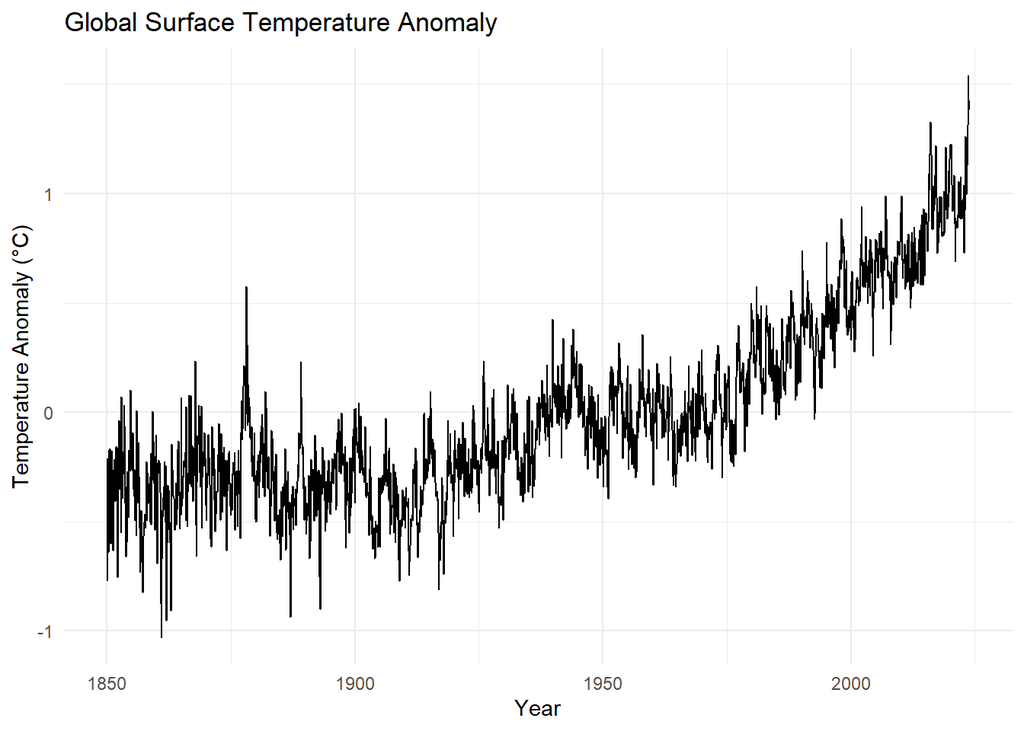

```r
ggplot(gst_anom, aes(x = as.Date(paste(Year, Month, "01", sep = "-")), y = Anomaly)) +
  geom_line() +
  labs(title = "Global Surface Temperature Anomaly",
       x = "Year", y = "Temperature Anomaly (°C)") +
  theme_minimal()
```

- The plotted data represents the Global Surface Temperature Anomaly over a period starting from approximately 1850 to 2023.
- During the latter part of the 20th century and extending into the 21st century, there is a noticeable upward trend in global surface temperature anomaly. This aligns with the widely accepted scientific consensus that global warming and climate change are driven by human activities such as burning fossil fuels.

The fastest increase in the temperature anomaly appears to have occurred in the last few decades, with recent years experiencing record-high temperature anomalies. This rapid warming aligns with the increase in greenhouse gas emissions and climate models projecting accelerated warming in the present era. Before the late 20th century, the temperature anomaly fluctuated around a relatively stable baseline, with occasional spikes that may be linked to natural events or measurement uncertainties in the early observational record.

The plot illustrates that the global temperature anomaly has varied between approximately -1.0°C to over 1.5°C in comparison to the baseline period, emphasizing the significant impact even small temperature changes can have on the global climate system.

```r
#creating a dataframe strating from 1990 and creating time sereis data
df_1990_onwards <- subset(gst_anom, Year >= 1990)
ts_data <- ts(df_1990_onwards$Anomaly, start = c(1990, 1), frequency = 12)
```

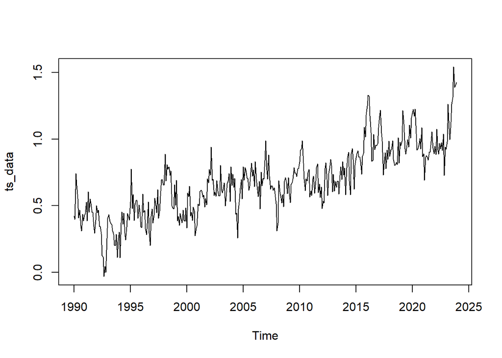

```r
ts.plot(ts_data)
```

```r
# check for the stationarity
adf.test(ts_data) ## p<0.05, The time series is stationary.
```

```
##
##  Augmented Dickey-Fuller Test
##
## data:  ts_data
## Dickey-Fuller = -4.8413, Lag order = 7, p-value = 0.01
## alternative hypothesis: stationary
```

- Based on the test reults we can say that the data is has stationarity since p-value <0.05.

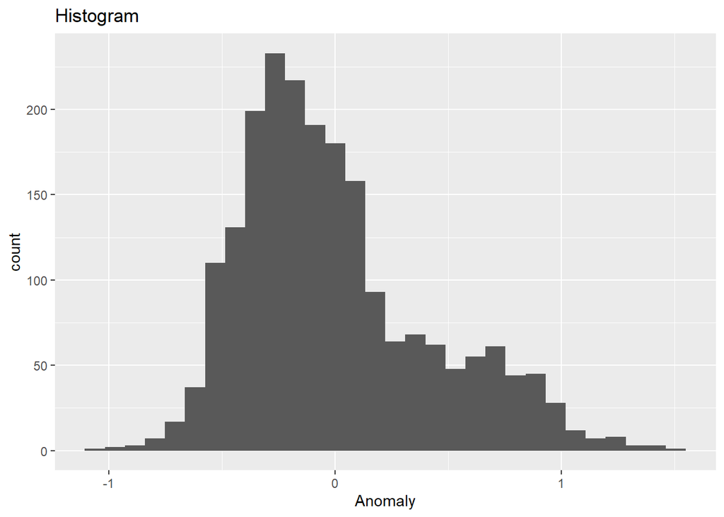

```r
ggplot(data = gst_anom, aes(x = Anomaly)) +
  geom_histogram(bins = 30) + labs(title = "Histogram")
```